# Data Visualization and ggplot Introduction

ggplot2 is a package that is part of the tidyverse.Tidyverse is a collection of R packages designed for data science that share an underlying design philosphy, grammar, and data structures.

[figure not shown]

## Overview

ggplot2 is a system for declaratively creating graphics. You provide the data, tell ggplot2 how to map variables to aesthetics, what graphical primitives to use, and it takes care of the details.

### Installation

```r
# The easiest way to get ggplot2 is to install the whole tidyverse:
install.packages("tidyverse")

# Alternatively, install just ggplot2:
install.packages("ggplot2")

# Or the development version from GitHub:
# install.packages("devtools")
devtools::install_github("tidyverse/ggplot2")
```

### Usage

It’s hard to succinctly describe how ggplot2 works because it embodies a deep philosophy of visualisation. However, in most cases you start with [`ggplot()`](https://ggplot2.tidyverse.org/reference/ggplot.html), supply a dataset and aesthetic mapping (with [`aes()`](https://ggplot2.tidyverse.org/reference/aes.html)). You then add on layers (like [`geom_point()`](https://ggplot2.tidyverse.org/reference/geom_point.html) or [`geom_histogram()`](https://ggplot2.tidyverse.org/reference/geom_freqpoly.html)), scales (like [`scale_colour_brewer()`](https://ggplot2.tidyverse.org/reference/scale_colour_brewer.html)), faceting specifications (like [`facet_wrap()`](https://ggplot2.tidyverse.org/reference/facet_wrap.html)) and coordinate systems (like [`coord_flip()`](https://ggplot2.tidyverse.org/reference/coord_flip.html)).

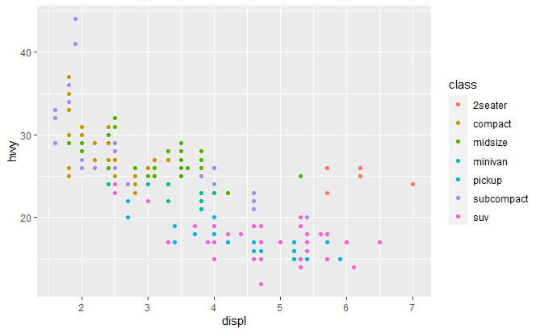

## Outline

1. 4 C’s of Data Visualization
- Clear - easily seen; sharply defined
- Clean - thorough; comlplete; unadulterated
- Concise - brief but comprehensive
- Captivating - to attract and hold by beauty or excellence
2. ggplot2 Overview
- Explore and Explain
- Data format for different plots
- Grammar of Graphics
- Basics components
  - Aesthetics
  - Geometries
  - Layers (Seven of them)
3. Aesthetics
- What they are and how they impact the visualization
- Color, Shape, Size
- Color vs. Fill
- Categorical vs Contiuous Data
- Attributes
- Best Practices
4. Geometries
- Scatter plots
- Histograms
- Bar plots
- Box plots
- Line plots
- Time series
5. Themes
- Using themes
- Creating custom themes
6. Next Steps and Resources